# Analyzing NFL Combine Invitees from 2000 to 2017

Introduction

In this tutorial, we will learn how to bring data through the data analytics process, by examining and analyzing data about players who were invited to the NFL Combine between 2000 and 2017. Similar to how it worked with the MLB, NFL coaches and owners can use data analytics to analyze statistics about players at the Combine to help them determine who they should draft based on their performance at the Combine. It is also a good dataset with regards to understanding the data science pipeline, because there is a lot of data, and it requires a lot of cleaning, so we can make useful plots as well as learn a decent amount about data wrangling and transformation.

```r
library(tidyverse)
```

Data Ingestion

To start, we will bring in all the data to RStudio. First, download the CSV files from Kaggle: https://www.kaggle.com/kbanta11/nfl-combine. Once you have done this, go into your file explorer and unzip the folder.

Next, we will use the read_csv function in R to bring in the data. Replace the path file in the function with your own path file for where your files are.

```r
offense_2000 <- read_csv("C:/Users/alysha/Downloads/nfl-combine/2000Offense.csv")
defense_2000 <- read_csv("C:/Users/alysha/Downloads/nfl-combine/2000Defense.csv")
offense_2001 <- read_csv("C:/Users/alysha/Downloads/nfl-combine/2001Offense.csv")
defense_2001 <- read_csv("C:/Users/alysha/Downloads/nfl-combine/2001Defense.csv")
offense_2002 <- read_csv("C:/Users/alysha/Downloads/nfl-combine/2002Offense.csv")
defense_2002 <- read_csv("C:/Users/alysha/Downloads/nfl-combine/2002Defense.csv")
offense_2003 <- read_csv("C:/Users/alysha/Downloads/nfl-combine/2003Offense.csv")
defense_2003 <- read_csv("C:/Users/alysha/Downloads/nfl-combine/2003Defense.csv")
offense_2004 <- read_csv("C:/Users/alysha/Downloads/nfl-combine/2004Offense.csv")
defense_2004 <- read_csv("C:/Users/alysha/Downloads/nfl-combine/2004Defense.csv")
offense_2005 <- read_csv("C:/Users/alysha/Downloads/nfl-combine/2005Offense.csv")
defense_2005 <- read_csv("C:/Users/alysha/Downloads/nfl-combine/2005Defense.csv")
offense_2006 <- read_csv("C:/Users/alysha/Downloads/nfl-combine/2006Offense.csv")
defense_2006 <- read_csv("C:/Users/alysha/Downloads/nfl-combine/2006Defense.csv")
offense_2007 <- read_csv("C:/Users/alysha/Downloads/nfl-combine/2007Offense.csv")
defense_2007 <- read_csv("C:/Users/alysha/Downloads/nfl-combine/2007Defense.csv")
offense_2008 <- read_csv("C:/Users/alysha/Downloads/nfl-combine/2008Offense.csv")
defense_2008 <- read_csv("C:/Users/alysha/Downloads/nfl-combine/2008Defense.csv")
offense_2009 <- read_csv("C:/Users/alysha/Downloads/nfl-combine/2009Offense.csv")
defense_2009 <- read_csv("C:/Users/alysha/Downloads/nfl-combine/2009Defense.csv")
offense_2010 <- read_csv("C:/Users/alysha/Downloads/nfl-combine/2010Offense.csv")
defense_2010 <- read_csv("C:/Users/alysha/Downloads/nfl-combine/2010Defense.csv")
offense_2011 <- read_csv("C:/Users/alysha/Downloads/nfl-combine/2011Offense.csv")
defense_2011 <- read_csv("C:/Users/alysha/Downloads/nfl-combine/2011Defense.csv")
offense_2012 <- read_csv("C:/Users/alysha/Downloads/nfl-combine/2012Offense.csv")
defense_2012 <- read_csv("C:/Users/alysha/Downloads/nfl-combine/2012Defense.csv")
offense_2013 <- read_csv("C:/Users/alysha/Downloads/nfl-combine/2013Offense.csv")
defense_2013 <- read_csv("C:/Users/alysha/Downloads/nfl-combine/2013Defense.csv")
offense_2014 <- read_csv("C:/Users/alysha/Downloads/nfl-combine/2014Offense.csv")
defense_2014 <- read_csv("C:/Users/alysha/Downloads/nfl-combine/2014Defense.csv")
offense_2015 <- read_csv("C:/Users/alysha/Downloads/nfl-combine/2015Offense.csv")
defense_2015 <- read_csv("C:/Users/alysha/Downloads/nfl-combine/2015Defense.csv")
offense_2016 <- read_csv("C:/Users/alysha/Downloads/nfl-combine/2016Offense.csv")
defense_2016 <- read_csv("C:/Users/alysha/Downloads/nfl-combine/2016Defense.csv")
offense_2017 <- read_csv("C:/Users/alysha/Downloads/nfl-combine/2017Offense.csv")
defense_2017 <- read_csv("C:/Users/alysha/Downloads/nfl-combine/2017Defense.csv")
```

Data Cleaning

Now, since each dataset already contains a column for the year, we can easily combine the datasets and still be able to know which year each player attended the Combine. However, the datasets do not contain a column telling us whether the player plays defense or offense, so for now we will only combine all the Defense datasets together, and all the Offense datasets together.

```r
all_offense <- rbind(offense_2000,offense_2001,offense_2002,offense_2003,offense_2004,offense_2005,offense_2006,offense_2007,offense_2008,offense_2009,offense_2010,offense_2011,offense_2012,offense_2013,offense_2014,offense_2015,offense_2016,offense_2017)

head(all_offense)
```

```
## # A tibble: 6 x 16
##   Rk    Year  Player      Pos   AV    School  College  Height Wt    `40YD`
##   <chr> <chr> <chr>       <chr> <chr> <chr>   <chr>    <chr>  <chr> <chr>
## 1 1     2000  "Bashir Ya~ WR    0     Iowa    College~ 6-3    191   4.53
## 2 2     2000  "Spergon W~ QB    2     Texas ~ College~ 6-3    229   4.91
## 3 3     2000  "James Wil~ WR    4     Marsha~ College~ 5-11   180   4.59
## 4 4     2000  "Bobbie Wi~ OT    64    Arkans~ <NA>     6-4    332   5.26
## 5 5     2000  "Michael W~ RB    4     Ohio S~ College~ 5-11   193   4.5
## 6 6     2000  "Dez White~ WR    19    Georgi~ College~ 6-1    218   4.62
## # ... with 6 more variables: Vertical <chr>, BenchReps <chr>, `Broad
## #   Jump` <chr>, `3Cone` <chr>, Shuttle <chr>, `Drafted (tm/rnd/yr)` <chr>
```

```r
all_defense <- rbind(defense_2000,defense_2001,defense_2002,defense_2003,defense_2004,defense_2005,defense_2006,defense_2007,defense_2008,defense_2009,defense_2010,defense_2011,defense_2012,defense_2013,defense_2014,defense_2015,defense_2016,defense_2017)

head(all_defense)
```

```
## # A tibble: 6 x 16
##      Rk  Year Player     Pos      AV School   College  Height    Wt `40YD`
##   <int> <int> <chr>      <chr> <int> <chr>    <chr>    <chr>  <int>  <dbl>
## 1     1  2000 "Brian Yo~ DE       47 Texas-E~ College~ 6-2      278   4.94
## 2     2  2000 "Cedric W~ DT       15 Texas    <NA>     6-2      290   5.21
## 3     3  2000 "Antonio ~ OLB       2 Texas A~ <NA>     6-2      245   4.56
## 4     4  2000 "Josh Wil~ DT       19 Michigan <NA>     6-3      282   4.90
## 5     5  2000 "Damen Wh~ CB        0 Colorado <NA>     5-9      179   4.51
## 6     6  2000 "Jason We~ CB       27 Texas A~ <NA>     5-9      180   4.42
## # ... with 6 more variables: Vertical <dbl>, BenchReps <int>, `Broad
## #   Jump` <int>, `3Cone` <dbl>, Shuttle <dbl>, `Drafted (tm/rnd/yr)` <chr>
```

In order to combine all the data into one dataset, while still being able to easily distinguish offensive from defensive players, what we can do is create a column indicating whether a player is offensive or defensive. In the offensive dataset, we will entirely populate this column with “Offense”, and in the defensive one, with “Defense”.

```r
all_offense$Side <- rep("Offense",nrow(all_offense))
all_defense$Side <- rep("Defense",nrow(all_defense))
head(all_offense)
```

```
## # A tibble: 6 x 17
##   Rk    Year  Player      Pos   AV    School  College  Height Wt    `40YD`
##   <chr> <chr> <chr>       <chr> <chr> <chr>   <chr>    <chr>  <chr> <chr>
## 1 1     2000  "Bashir Ya~ WR    0     Iowa    College~ 6-3    191   4.53
## 2 2     2000  "Spergon W~ QB    2     Texas ~ College~ 6-3    229   4.91
## 3 3     2000  "James Wil~ WR    4     Marsha~ College~ 5-11   180   4.59
## 4 4     2000  "Bobbie Wi~ OT    64    Arkans~ <NA>     6-4    332   5.26
## 5 5     2000  "Michael W~ RB    4     Ohio S~ College~ 5-11   193   4.5
## 6 6     2000  "Dez White~ WR    19    Georgi~ College~ 6-1    218   4.62
## # ... with 7 more variables: Vertical <chr>, BenchReps <chr>, `Broad
## #   Jump` <chr>, `3Cone` <chr>, Shuttle <chr>, `Drafted
## #   (tm/rnd/yr)` <chr>, Side <chr>
```

```r
head(all_defense)
```

```
## # A tibble: 6 x 17
##      Rk  Year Player     Pos      AV School   College  Height    Wt `40YD`
##   <int> <int> <chr>      <chr> <int> <chr>    <chr>    <chr>  <int>  <dbl>
## 1     1  2000 "Brian Yo~ DE       47 Texas-E~ College~ 6-2      278   4.94
## 2     2  2000 "Cedric W~ DT       15 Texas    <NA>     6-2      290   5.21
## 3     3  2000 "Antonio ~ OLB       2 Texas A~ <NA>     6-2      245   4.56
## 4     4  2000 "Josh Wil~ DT       19 Michigan <NA>     6-3      282   4.90
## 5     5  2000 "Damen Wh~ CB        0 Colorado <NA>     5-9      179   4.51
## 6     6  2000 "Jason We~ CB       27 Texas A~ <NA>     5-9      180   4.42
## # ... with 7 more variables: Vertical <dbl>, BenchReps <int>, `Broad
## #   Jump` <int>, `3Cone` <dbl>, Shuttle <dbl>, `Drafted
## #   (tm/rnd/yr)` <chr>, Side <chr>
```

Now, we are ready to combine the datasets and get to the actual data cleaning.

```r
all_players <- rbind(all_offense,all_defense)

head(all_players)
```

```
## # A tibble: 6 x 17
##   Rk    Year  Player      Pos   AV    School  College  Height Wt    `40YD`
##   <chr> <chr> <chr>       <chr> <chr> <chr>   <chr>    <chr>  <chr> <chr>
## 1 1     2000  "Bashir Ya~ WR    0     Iowa    College~ 6-3    191   4.53
## 2 2     2000  "Spergon W~ QB    2     Texas ~ College~ 6-3    229   4.91
## 3 3     2000  "James Wil~ WR    4     Marsha~ College~ 5-11   180   4.59
## 4 4     2000  "Bobbie Wi~ OT    64    Arkans~ <NA>     6-4    332   5.26
## 5 5     2000  "Michael W~ RB    4     Ohio S~ College~ 5-11   193   4.5
## 6 6     2000  "Dez White~ WR    19    Georgi~ College~ 6-1    218   4.62
## # ... with 7 more variables: Vertical <chr>, BenchReps <chr>, `Broad
## #   Jump` <chr>, `3Cone` <chr>, Shuttle <chr>, `Drafted
## #   (tm/rnd/yr)` <chr>, Side <chr>
```

Looking at the “Player” column, we can see that this column contains a player’s name, followed by a backslash character, followed by what appears to be an identification code for the player. Rather than having both of these in one column, it will be visually easier to look at them separately, so we will separate this into 2 columns.

```r
all_players <- separate(all_players,Player,c("PlayerName","PlayerID"),sep="[\\\\]",remove=TRUE)
head(all_players)
```

```
## # A tibble: 6 x 18
##   Rk    Year  PlayerName  PlayerID Pos   AV    School College Height Wt
##   <chr> <chr> <chr>       <chr>    <chr> <chr> <chr>  <chr>   <chr>  <chr>
## 1 1     2000  Bashir Yam~ YamiBa20 WR    0     Iowa   Colleg~ 6-3    191
## 2 2     2000  Spergon Wy~ WynnSp00 QB    2     Texas~ Colleg~ 6-3    229
## 3 3     2000  James Will~ WillJa01 WR    4     Marsh~ Colleg~ 5-11   180
## 4 4     2000  Bobbie Wil~ WillBo21 OT    64    Arkan~ <NA>    6-4    332
## 5 5     2000  Michael Wi~ WileMi00 RB    4     Ohio ~ Colleg~ 5-11   193
## 6 6     2000  Dez White   WhitDe00 WR    19    Georg~ Colleg~ 6-1    218
## # ... with 8 more variables: `40YD` <chr>, Vertical <chr>,
## #   BenchReps <chr>, `Broad Jump` <chr>, `3Cone` <chr>, Shuttle <chr>,
## #   `Drafted (tm/rnd/yr)` <chr>, Side <chr>
```

Another column we will want to separate is the “Drafted” column. This column actually contains 4 separate values: what team a player was drafted by, what round they were drafted in, what number pick they were overall, and what year they were drafted. We can separate this into 4 separate columns so we can look at the information individually.

```r
all_players <- separate(all_players,"Drafted (tm/rnd/yr)",c("Team","Round","PickOverall","YearDrafted"),sep="/",remove=TRUE)
```

```
## Warning: Too few values at 1 locations: 330
```

```r
head(all_players)
```

```
## # A tibble: 6 x 21
##   Rk    Year  PlayerName  PlayerID Pos   AV    School College Height Wt
##   <chr> <chr> <chr>       <chr>    <chr> <chr> <chr>  <chr>   <chr>  <chr>
## 1 1     2000  Bashir Yam~ YamiBa20 WR    0     Iowa   Colleg~ 6-3    191
## 2 2     2000  Spergon Wy~ WynnSp00 QB    2     Texas~ Colleg~ 6-3    229
## 3 3     2000  James Will~ WillJa01 WR    4     Marsh~ Colleg~ 5-11   180
## 4 4     2000  Bobbie Wil~ WillBo21 OT    64    Arkan~ <NA>    6-4    332
## 5 5     2000  Michael Wi~ WileMi00 RB    4     Ohio ~ Colleg~ 5-11   193
## 6 6     2000  Dez White   WhitDe00 WR    19    Georg~ Colleg~ 6-1    218
## # ... with 11 more variables: `40YD` <chr>, Vertical <chr>,
## #   BenchReps <chr>, `Broad Jump` <chr>, `3Cone` <chr>, Shuttle <chr>,
## #   Team <chr>, Round <chr>, PickOverall <chr>, YearDrafted <chr>,
## #   Side <chr>
```

Doing this reveals, in the form of a warning, that we have a weirdly formatted row. Looking at this row, and comparing it to the original data, reveals that one of our files started with a blank line, causing the header to be interpreted as a row. So, we will delete that row.

```r
all_players <- all_players[-c(330), ]

head(all_players)
```

```
## # A tibble: 6 x 21
##   Rk    Year  PlayerName  PlayerID Pos   AV    School College Height Wt
##   <chr> <chr> <chr>       <chr>    <chr> <chr> <chr>  <chr>   <chr>  <chr>
## 1 1     2000  Bashir Yam~ YamiBa20 WR    0     Iowa   Colleg~ 6-3    191
## 2 2     2000  Spergon Wy~ WynnSp00 QB    2     Texas~ Colleg~ 6-3    229
## 3 3     2000  James Will~ WillJa01 WR    4     Marsh~ Colleg~ 5-11   180
## 4 4     2000  Bobbie Wil~ WillBo21 OT    64    Arkan~ <NA>    6-4    332
## 5 5     2000  Michael Wi~ WileMi00 RB    4     Ohio ~ Colleg~ 5-11   193
## 6 6     2000  Dez White   WhitDe00 WR    19    Georg~ Colleg~ 6-1    218
## # ... with 11 more variables: `40YD` <chr>, Vertical <chr>,
## #   BenchReps <chr>, `Broad Jump` <chr>, `3Cone` <chr>, Shuttle <chr>,
## #   Team <chr>, Round <chr>, PickOverall <chr>, YearDrafted <chr>,
## #   Side <chr>
```

There is one more column whose format we might want to clean up. Looking at players heights, it would be difficult to analyze these heights when they are in the format of “feet-inches”. So, we will convert this to total inches, so it is a purely numerical column.

```r
all_players <- separate(all_players,"Height",c("Feet","Inches"),sep="-",remove=FALSE)
all_players$Feet <- as.numeric(all_players$Feet) * 12
all_players$Feet <- all_players$Feet + as.numeric(all_players$Inches)
all_players <- rename(all_players,HeightInInches=Feet)
all_players <- select(all_players,-Inches)

head(all_players)
```

```
## # A tibble: 6 x 22
##   Rk    Year  PlayerName    PlayerID Pos   AV    School   College   Height
##   <chr> <chr> <chr>         <chr>    <chr> <chr> <chr>    <chr>     <chr>
## 1 1     2000  Bashir Yamini YamiBa20 WR    0     Iowa     College ~ 6-3
## 2 2     2000  Spergon Wynn  WynnSp00 QB    2     Texas S~ College ~ 6-3
## 3 3     2000  James Willia~ WillJa01 WR    4     Marshall College ~ 5-11
## 4 4     2000  Bobbie Willi~ WillBo21 OT    64    Arkansas <NA>      6-4
## 5 5     2000  Michael Wiley WileMi00 RB    4     Ohio St~ College ~ 5-11
## 6 6     2000  Dez White     WhitDe00 WR    19    Georgia~ College ~ 6-1
## # ... with 13 more variables: HeightInInches <dbl>, Wt <chr>,
## #   `40YD` <chr>, Vertical <chr>, BenchReps <chr>, `Broad Jump` <chr>,
## #   `3Cone` <chr>, Shuttle <chr>, Team <chr>, Round <chr>,
## #   PickOverall <chr>, YearDrafted <chr>, Side <chr>
```

Now that all the data is formatted the way we want, we can start analyzing it. Something basic that we might want to look at is what positions have the most representation at the combine. We will do this by plotting each position against the number of players that it had in the Combine from 2000 to 2017.

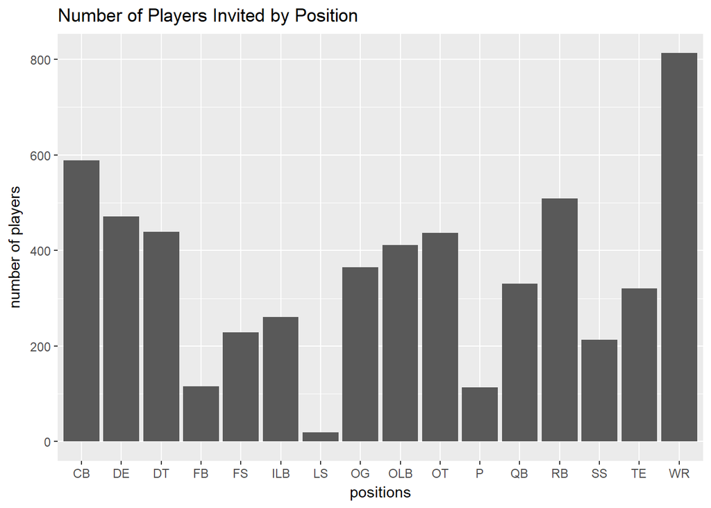

```r
all_players %>%
  ggplot(mapping=aes(x=Pos,y=..count..)) + geom_bar() + labs(title="Number of Players Invited by Position",x="positions",y="number of players")
```

Looking at this plot, we can see that mostly wide receivers are invited to the NFL Combine, followed by cornerbacks and running backs. The position that is least often invited to the Combine is long snapper.

We also might want to know whether more offensive or defensive players are invited to the Combine. To do this, we will look at the “Side” column, and plot each side against the number of players that it had in the Combine from 2000 to 2017.

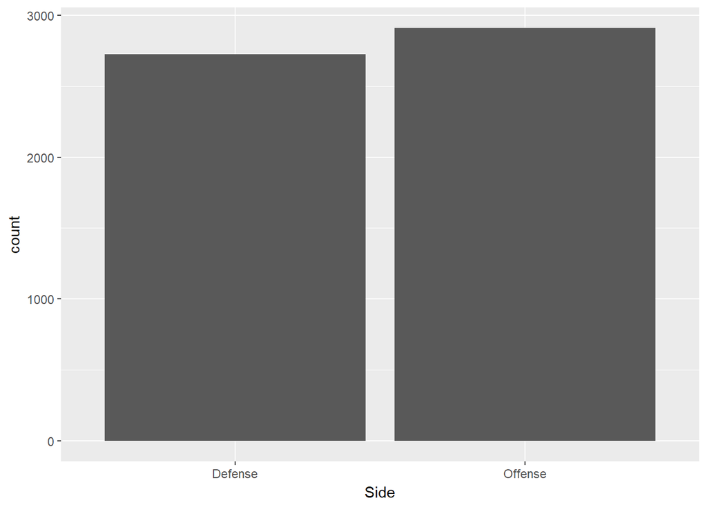

```r
all_players %>%
  ggplot(mapping=aes(x=Side,y=..count..)) + geom_bar()
```

As it turns out, NFL teams don’t seem to strongly favor one side over the other – the bar graph shows us that offensive and defensive players have had fairly similar representation over this time period.

Something that you may have noticed from the data frame is that not all players were actually drafted after the Combine. Given that these players were considered good enough to be invited to the Combine, we might wonder if their performance at the Combine is what caused them not to be drafted. To determine this, we can look at some of the average statistics for drafted players vs. undrafted players. First, we will create a column telling us if a player was drafted or not, based on if there is a team in their “Team” column or not.

```r
all_players <- mutate(all_players,"DraftStatus"=ifelse(is.na(Team),"Undrafted","Drafted"))

head(all_players)
```

```
## # A tibble: 6 x 23
##   Rk    Year  PlayerName    PlayerID Pos   AV    School   College   Height
##   <chr> <chr> <chr>         <chr>    <chr> <chr> <chr>    <chr>     <chr>
## 1 1     2000  Bashir Yamini YamiBa20 WR    0     Iowa     College ~ 6-3
## 2 2     2000  Spergon Wynn  WynnSp00 QB    2     Texas S~ College ~ 6-3
## 3 3     2000  James Willia~ WillJa01 WR    4     Marshall College ~ 5-11
## 4 4     2000  Bobbie Willi~ WillBo21 OT    64    Arkansas <NA>      6-4
## 5 5     2000  Michael Wiley WileMi00 RB    4     Ohio St~ College ~ 5-11
## 6 6     2000  Dez White     WhitDe00 WR    19    Georgia~ College ~ 6-1
## # ... with 14 more variables: HeightInInches <dbl>, Wt <chr>,
## #   `40YD` <chr>, Vertical <chr>, BenchReps <chr>, `Broad Jump` <chr>,
## #   `3Cone` <chr>, Shuttle <chr>, Team <chr>, Round <chr>,
## #   PickOverall <chr>, YearDrafted <chr>, Side <chr>, DraftStatus <chr>
```

Now, we can display certain statistics for both drafted and undrafted players.

```r
#all_players$"40YD" <- as.numeric(all_players$"40YD")
```